# Ex2 - Fakebook bus

Jennifer Liu

2024-03-26

```r
seat_adjacency = read.csv("C:\\Users\\Admin\\Downloads\\Fakebook Bus.csv")
head(seat_adjacency)
```

```
##   From To
## 1    1  2
## 2    2  1
## 3    2  A
## 4    A  2
## 5    A  B
## 6    A  C
```

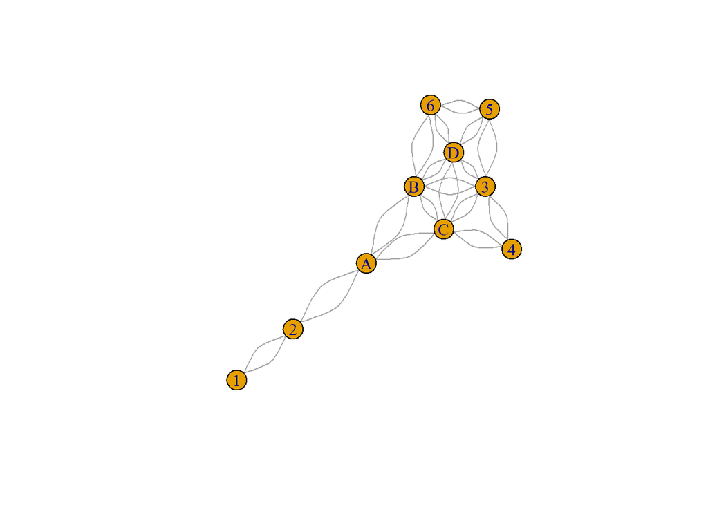

```r
graph = graph_from_data_frame(seat_adjacency, directed = FALSE)

plot(graph)
```

```r
# Calculate centrality measures for the relevant seats
degree_centrality = degree(graph, v=c("A","B","C","D"))

closeness_centrality = closeness(graph, v=c("A","B","C","D"))

betweenness_centrality = betweenness(graph, v=c("A","B","C","D"))
```

```r
degree_centrality
```

```
##  A  B  C  D
##  6 10 10 10
```

```r
closeness_centrality
```

```
##          A          B          C          D
## 0.06250000 0.07142857 0.07142857 0.06250000
```

```r
betweenness_centrality
```

```
##         A         B         C         D
## 14.000000  9.033333  8.600000  3.266667
```

```r
# Combine and display the centrality measures
centrality_measures = data.frame(
  Seat = c("A","B","C","D"),
  Degree = degree_centrality,
  Closeness = closeness_centrality,
  Betweenness = betweenness_centrality
)

# Print the centrality measures
print(centrality_measures)
```

```
##   Seat Degree  Closeness Betweenness
## A    A      6 0.06250000   14.000000
## B    B     10 0.07142857    9.033333
## C    C     10 0.07142857    8.600000
## D    D     10 0.06250000    3.266667
```

[figure not shown]

```r
# Plot the network graph
plot(graph, vertex.size=degree_centrality, layout=layout_with_kk(graph))
```

## Possible Consequences of Seat Choice

Based on the centrality measures calculated from the Fakebook bus seating arrangement, we can conclude:

### When would this choice be beneficial?

- **Enhanced Networking Opportunities**: A seat with high degree centrality, like Seat B, would provide numerous direct connections. This setup is advantageous for fostering a wide network, allowing for easy communication with many colleagues during the commute. It’s particularly beneficial for someone looking to establish a broad range of contacts quickly within the company.
- **Central Information Node**: Opting for a seat with high closeness centrality means being strategically positioned to access information efficiently. This seat choice benefits those who aim to be at the heart of communication, facilitating faster exchange of news, insights, and resources across the network.
- **Strategic Influence**: A seat with high betweenness centrality positions you as a key connector between different groups. This can be beneficial for exerting influence and playing a crucial role in the dissemination of information, making it an ideal choice for individuals looking to establish themselves as integral members of the company’s social and communication networks.

## When would it be not so beneficial?

- **Risk of Overexposure**: Being in a seat with high degree and closeness centralities means being more visible and accessible, which can lead to constant engagement with colleagues. This might be less beneficial for individuals who value privacy, quiet, or focused time during their commute.
- **Potential for Overload**: A central position in the network could result in information overload or excessive social demands. This can be counterproductive for those who need a more relaxed environment to prepare for the day ahead or unwind after work.
- **Dependency Creation**: High betweenness centrality can create a dependency, where you become the primary route for information or communication between different network segments. While this can be beneficial for building influence, it might also place undue pressure and responsibility on you, especially as an intern still acclimating to the company culture and environment.

[figure not shown]

```r
# Define node labels to include centrality measures
node_labels <- paste(c("A","B","C","D"),
                     "\nDegree:", round(degree_centrality, 2),
                     "\nCloseness:", round(closeness_centrality, 2),
                     "\nBetweenness:", round(betweenness_centrality, 2))
par(mar = c(1, 1, 1, 1))
layout <- layout_nicely(graph)
# Plot the network graph with the labels
plot(graph,
     layout = layout_with_kk(graph),
     vertex.label = node_labels,
     vertex.size = degree_centrality*2,
     edge.width = 3,
     edge.color = "black",
     main = "Network Graph with Centrality Measures",
     vertex.label.cex = 0.8,
     edge.arrow.size=0.3,
     vertex.label.family = "sans")
```